# L18_slides slides

## Today

1. Any Qs before we start?
2. Regressions
   - vocab
   - statistically vs. economically significant
   - a (brief) discussion of causality

## Vocab

Let's cover:

- "null hypothesis"
- std errors
- t-stats
- p-values
- economic significance

## Vocab via example

Last class, we estimated a model:

$$ intrate = a + b * CredScore + u$$

- The **null hypothesis** we are testing is: "Credit score is NOT related to the interest rate" ($\beta=0$)
- Testable: Can we **reject the null**? (Establish $\beta \neq 0$?)
- Not testable: Accepting the null (Establish $\beta = 0$?)

Example: A covid test

- Null hypo: I don't have Covid
- Reject: I do have Covid :(
- Negative test means "I can't reject the null that I don't have covid"
- Negative test does not mean: "I don't have covid"

Our model gave us this output:

| var | coef | std err | t | P>t |
| --- | --- | --- | --- | --- |
| Intercept | 11.5819 | 0.046 | 253.270 | 0.000 |
| CredScore | -0.0086 | 6.14e-05 | -139.198 | 0.000 |

- The coefficient column is the estimates of $\hat{a}$ and $\hat{b}$, (hats denote estimates)
- There is uncertainty in those estimates. Again:

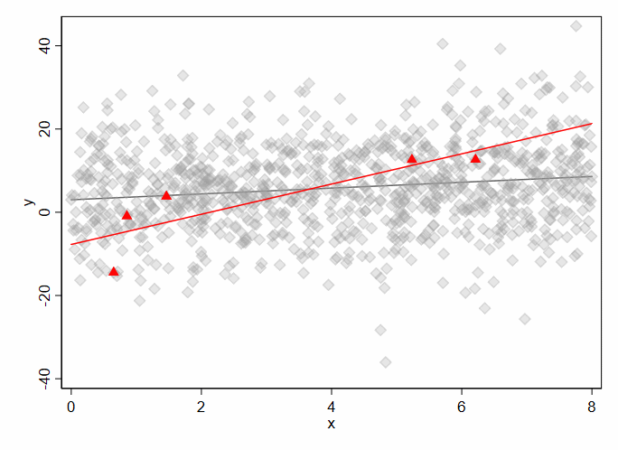

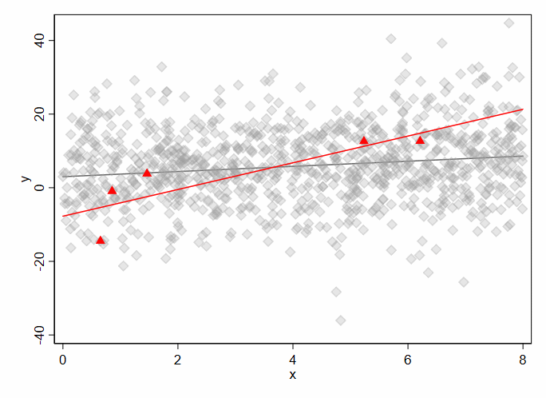

Our model gave us this output:

| var | coef | std err | t | P>t |
| --- | --- | --- | --- | --- |
| Intercept | 11.5819 | 0.046 | 253.270 | 0.000 |
| CredScore | -0.0086 | 6.14e-05 | -139.198 | 0.000 |

- The coefficient column is the estimates of $\hat{a}$ and $\hat{b}$, (hats denote estimates)
- **Std err** estimates std deviation of the coef
- **t-stat:** beta/se
- **p-value** (P>|t|): what is the probability that my non-zero beta is not zero, by random chance?
  - the lower it is, the more "certain" we can be that the relationship isn't zero
  - In tables, 1 star means p<10%, **2 means p<5%**, 3 means p<1%

## So you run a regression

... and a variable has a p-value below 5%.

Party?!

Not yet!

## A "statistically significant relationship between X and Y" **DOES NOT MEAN SIGNIFICANT**

**"Economic significance"** matters: Stat sig but economically trivial = yawn

Loose definition: Is a "reasonable" change in X assoc with a "large" change in y?

- Former: $\beta$ captures a one unit change, which might be tiny or huge
- Good trick: [Scale *continuous* variables by their STD](https://ledatascifi.github.io/ledatascifi-2022/content/05/02d_interpretingCoefs.html#comparing-the-size-of-two-coefficients) so that a one unit change in X is a STD.
- Latter: Compare to avg and std of y

## So you run a regression

... and a variable has a p-value below 5%.

... and the relationship is large enough to be meaningful.

Party?!

Not yet!

## Everyone who confuses correlation with causation eventually ends up dead

More commonly: "Correlation is not causation"

Reasons your (significant) correlation ain't causation:

- [It's spurious](https://www.tylervigen.com/spurious-correlations)
- [You p-hacked](https://fivethirtyeight.com/features/science-isnt-broken/#part1)
  - **Your focus should be on testing and evaluating a hypothesis, not "finding a result"**
- Omitted variables ("CEO ability","firm quality")
  - One version: [Simpson's paradox](https://www2.stat.duke.edu/courses/Fall12/sta611/SimpsonsParadox.pdf#page=11) can be [found many places](https://stats.stackexchange.com/questions/185047/is-this-simpsons-paradox-on-the-titanic-data-set) and sometimes [can be fixed with fixed effects](https://ledatascifi.github.io/ledatascifi-2022/content/05/02d_interpretingCoefs.html#if-other-categorical-controls-are-included), which looks [like this](https://lh3.googleusercontent.com/I2b6QpMjrU6vzaHtUbemQxH0a1ELycU6zu_WFZ0JD9DIbAxvmeB5VjMVl0h1c8GyN7MkjEGPbNZFGT01utgoaPT1O35wxAqgoUkKtKdzVnY6iD18iFuOzP4-_e3_0e0Lmg=w1280)
- Mismeasurement of an **X** variable (IQ for "CEO ability", MTB for marginal Q)
  - Look out for "proxies"
  - [Mismeasurement in y just raises SE](https://lh4.googleusercontent.com/huCelUD2P4BpKESfJ3lKoYr5AUyAyYATfs4sAC37iCRjK858lTYEuKakcEDvbeVId3Gxwl5SH9UtnhVb09y1PYxHYeVdcppdAEIhDsa9OptYdAYJkZJKR0vcQdz4gk3Y=w1280)
  - [(Classical) Mismeasurement in X causes attenuation](https://sites.google.com/view/robertostling/home/teaching)
- Simultaneity (think: "equilibrium outcomes")

## Everyone who confuses correlation with causation eventually ends up dead

More commonly: "Correlation is not causation"

Reasons your (significant) correlation ain't causation:

- [It's spurious](https://www.tylervigen.com/spurious-correlations)
- [You p-hacked](https://fivethirtyeight.com/features/science-isnt-broken/#part1)
- Omitted variables ("CEO ability","firm quality")
- Mismeasurement of an **X** variable (IQ for "CEO ability", MTB for marginal Q)
- Simultaneity (think: "equilibrium outcomes")
- Reverse causality
- Sample selection (effect of diversification of a firm on profitability)
  - Selection on X is bad
  - Selection on Y is superbad

## Summary

### The goal of this kind of analysis

**Is NOT predicting the interest rate** ($\hat{y}$ focused)

- Model fit is NOT the focus

The goal here is to understand what variables matter ($\hat{\beta}$ focused):

- For which X is the relationship $\hat{\beta}$ non-zero?
  - Detect rejection of the null via P-value
- Is the relationship *economically important*?
  - Size of coefficient
- Usually: **Is the relationship causal?**
  - Requires (psuedo) random variation in X
  - If causal, why? (What is the "mechanism" of causality?)
- If not causal: We say it is "descriptive"

## Discussion time

- Where does your post on the discussion board fit into the issues outlined above?
- Tell others about your post
- Dig into one link

## Next week

- I need team names to make project repos